# Diet exploration

Author

Emily Nazario

Published

January 31, 2024

## Diet data by year

Here is the diet data by year for the area, FL range, and time period included in the new study parameters. All columns should be how they are typically referenced with the addition of the `pred_metric` column. This is a new one I added representing the unique number of stomachs for that year, which was used to calculate the percent frequency value for each prey item.

| Year | Common_Name | N | W | Freq | pred_metric | perc_N | perc_W | perc_F | GII | perc_GII |
| --- | --- | --- | --- | --- | --- | --- | --- | --- | --- | --- |
| 2004 | Barracudina, Duckbill | 7 | 0.10 | 1 | 27 | 10.1449275 | 0.0006721 | 3.703704 | 7.995899 | 4.616435 |
| 2004 | Barracudinas | 3 | 29.20 | 1 | 27 | 4.3478261 | 0.1962660 | 3.703704 | 4.761867 | 2.749265 |
| 2004 | Fish, Unidentified | 10 | 298.70 | 5 | 27 | 14.4927536 | 2.0076934 | 18.518518 | 20.218209 | 11.672989 |
| 2004 | Grenadier, Pacific | 1 | 151.30 | 1 | 27 | 1.4492754 | 1.0169535 | 3.703704 | 3.562212 | 2.056644 |
| 2004 | Mackerel, Jack | 2 | 399.91 | 2 | 27 | 2.8985507 | 2.6879700 | 7.407407 | 7.502048 | 4.331309 |
| 2004 | Mackerel, Pacific | 1 | 52.80 | 1 | 27 | 1.4492754 | 0.3548919 | 3.703704 | 3.179971 | 1.835957 |
| 2004 | Mullet, Striped | 10 | 3025.50 | 7 | 27 | 14.4927536 | 20.3357089 | 25.925926 | 35.076563 | 20.251463 |
| 2004 | Rockfish, Shortbelly | 6 | 593.00 | 1 | 27 | 8.6956522 | 3.9858124 | 3.703704 | 9.459981 | 5.461723 |
| 2004 | Sanddab, Pacific | 1 | 0.01 | 1 | 27 | 1.4492754 | 0.0000672 | 3.703704 | 2.975113 | 1.717682 |
| 2004 | Scombroidei | 1 | 58.90 | 1 | 27 | 1.4492754 | 0.3958927 | 3.703704 | 3.203643 | 1.849624 |
| 2004 | Squid, Clubhook sp. | 2 | 0.01 | 1 | 27 | 2.8985507 | 0.0000672 | 3.703704 | 3.811852 | 2.200774 |
| 2004 | Squid, Cock-eyed | 1 | 0.10 | 1 | 27 | 1.4492754 | 0.0006721 | 3.703704 | 2.975462 | 1.717884 |
| 2004 | Squid, Flowervase Jewell | 1 | 0.10 | 1 | 27 | 1.4492754 | 0.0006721 | 3.703704 | 2.975462 | 1.717884 |
| 2004 | Squid, Jumbo | 15 | 9546.21 | 13 | 27 | 21.7391304 | 64.1642531 | 48.148148 | 77.394688 | 44.683844 |
| 2004 | Squid, Market | 1 | 0.10 | 1 | 27 | 1.4492754 | 0.0006721 | 3.703704 | 2.975462 | 1.717884 |
| 2004 | Squid, Unidentified | 5 | 130.03 | 4 | 27 | 7.2463768 | 0.8739885 | 14.814815 | 13.241632 | 7.645060 |
| 2004 | Squids, Jewell/Umbrella | 1 | 0.10 | 1 | 27 | 1.4492754 | 0.0006721 | 3.703704 | 2.975462 | 1.717884 |
| 2004 | Tuna, Skipjack | 1 | 591.70 | 1 | 27 | 1.4492754 | 3.9770745 | 3.703704 | 5.271239 | 3.043351 |
| 2005 | Barracudinas | 1 | 0.40 | 1 | 22 | 1.1764706 | 0.0183753 | 4.545454 | 3.314164 | 1.913434 |
| 2005 | Fish, Unidentified | 3 | 63.40 | 3 | 22 | 3.5294118 | 2.9124786 | 13.636364 | 11.592185 | 6.692751 |
| 2005 | Grenadier, Pacific | 1 | 136.80 | 1 | 22 | 1.1764706 | 6.2843388 | 4.545454 | 6.931820 | 4.002088 |
| 2005 | Mackerel, Pacific | 14 | 424.20 | 5 | 22 | 16.4705882 | 19.4869628 | 22.727273 | 33.881699 | 19.561608 |
| 2005 | Mullet, Striped | 1 | 43.40 | 1 | 22 | 1.1764706 | 1.9937157 | 4.545454 | 4.454627 | 2.571880 |
| 2005 | Sardine, Pacific | 14 | 141.10 | 4 | 22 | 16.4705882 | 6.4818728 | 18.181818 | 23.748887 | 13.711426 |
| 2005 | Saury, Pacific | 33 | 703.10 | 5 | 22 | 38.8235294 | 32.2991125 | 22.727273 | 54.184274 | 31.283305 |
| 2005 | Squid, Flowervase Jewell | 1 | 0.01 | 1 | 22 | 1.1764706 | 0.0004594 | 4.545454 | 3.303820 | 1.907461 |
| 2005 | Squid, Gonatus sp. | 1 | 0.10 | 1 | 22 | 1.1764706 | 0.0045938 | 4.545454 | 3.306207 | 1.908840 |
| 2005 | Squid, Jumbo | 9 | 500.00 | 5 | 22 | 10.5882353 | 22.9690744 | 22.727273 | 32.495919 | 18.761527 |
| 2005 | Squid, Market | 2 | 0.02 | 2 | 22 | 2.3529412 | 0.0009188 | 9.090909 | 6.607640 | 3.814923 |
| 2005 | Squid, Unidentified | 1 | 162.10 | 1 | 22 | 1.1764706 | 7.4465739 | 4.545454 | 7.602837 | 4.389500 |

[output cut: 67 more lines]

## GII bar plots

Below are bar plots of the %GII for each prey species by year. Plots are organized from highest to lowest %GII. These %GII values were calculated using the data table above (filtered according to the new study parameters). %GII values less than 1 were not plotted. An important note is that weak El Niño events occurred in 2004-2005 and 2006-2007, while moderate El Niño events occurred in 2009-2010. Additionally, weak La Niña events occurred in 2005-2006 and 2008-2009, while strong La Niña events occurred in 2007-2008.

**All years**

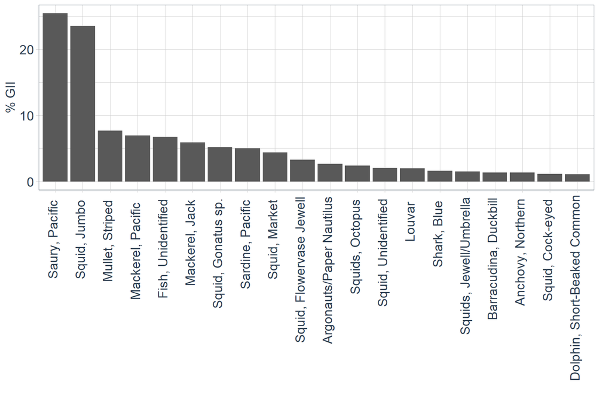

**2004**

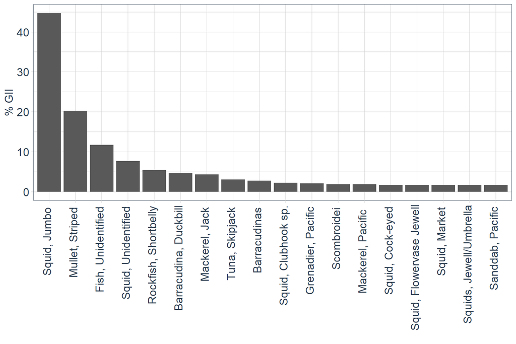

**2005**

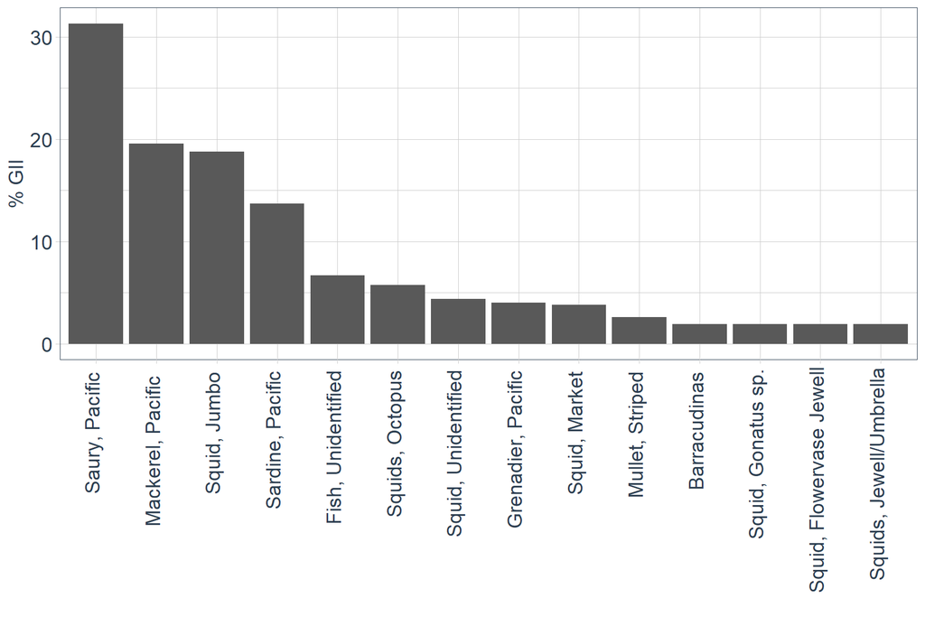

**2006**

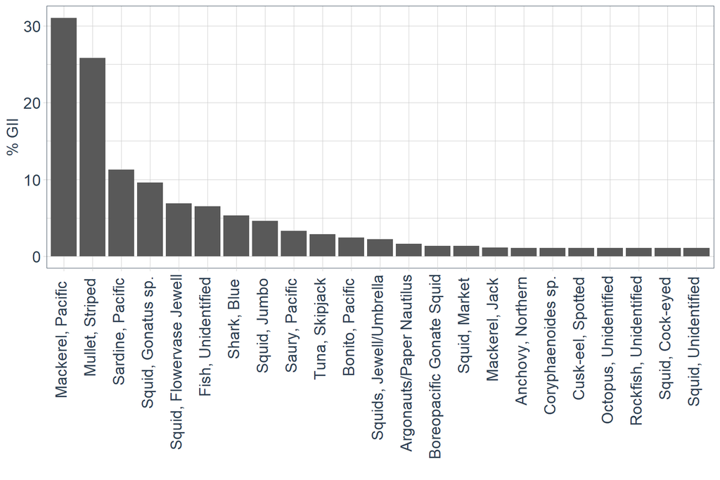

**2007**

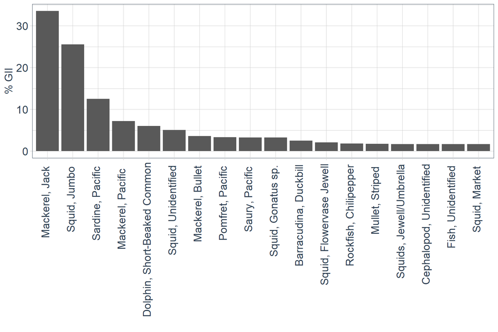

**2008**

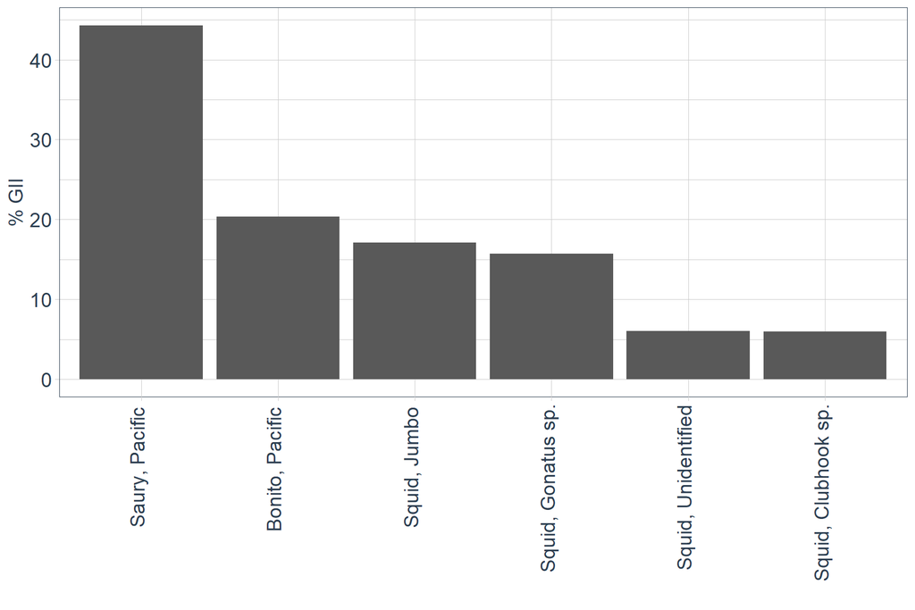

**2009**

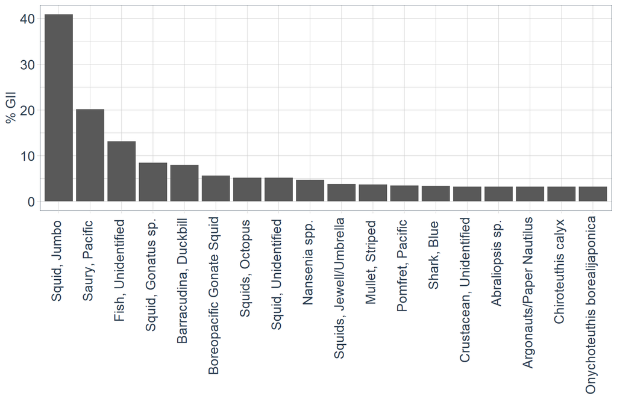